# Optimal Treatment Analysis

## Outcome Variable

**Outcome Variable:** whz

## Predictor Variables

**Intervention Variable:** mwtkg

**Adjustment Set:**

- arm
- W_mage
- meducyrs
- feducyrs
- hhwealth_quart
- brthmon
- W_parity
- impfloor
- impsan
- safeh20
- delta_W_mage
- delta_meducyrs
- delta_feducyrs
- delta_hhwealth_quart
- delta_brthmon
- delta_W_parity
- delta_impfloor
- delta_impsan
- delta_safeh20

## Stratifying Variables

The analysis was stratified on these variable(s):

- agecat
- studyid
- country

## Data Summary

| agecat | studyid | country | mwtkg | n_cell | n |
| --- | --- | --- | --- | --- | --- |
| Birth | ki0047075b-MAL-ED | BANGLADESH | >=58 kg | 37 | 209 |
| Birth | ki0047075b-MAL-ED | BANGLADESH | <52 kg | 131 | 209 |
| Birth | ki0047075b-MAL-ED | BANGLADESH | [52-58) kg | 41 | 209 |
| Birth | ki0047075b-MAL-ED | BRAZIL | >=58 kg | 33 | 61 |
| Birth | ki0047075b-MAL-ED | BRAZIL | <52 kg | 14 | 61 |
| Birth | ki0047075b-MAL-ED | BRAZIL | [52-58) kg | 14 | 61 |
| Birth | ki0047075b-MAL-ED | INDIA | >=58 kg | 6 | 41 |
| Birth | ki0047075b-MAL-ED | INDIA | <52 kg | 28 | 41 |
| Birth | ki0047075b-MAL-ED | INDIA | [52-58) kg | 7 | 41 |
| Birth | ki0047075b-MAL-ED | NEPAL | >=58 kg | 9 | 26 |
| Birth | ki0047075b-MAL-ED | NEPAL | <52 kg | 7 | 26 |
| Birth | ki0047075b-MAL-ED | NEPAL | [52-58) kg | 10 | 26 |
| Birth | ki0047075b-MAL-ED | PERU | >=58 kg | 82 | 221 |
| Birth | ki0047075b-MAL-ED | PERU | <52 kg | 81 | 221 |
| Birth | ki0047075b-MAL-ED | PERU | [52-58) kg | 58 | 221 |
| Birth | ki0047075b-MAL-ED | SOUTH AFRICA | >=58 kg | 69 | 100 |
| Birth | ki0047075b-MAL-ED | SOUTH AFRICA | <52 kg | 10 | 100 |
| Birth | ki0047075b-MAL-ED | SOUTH AFRICA | [52-58) kg | 21 | 100 |
| Birth | ki0047075b-MAL-ED | TANZANIA, UNITED REPUBLIC OF | >=58 kg | 44 | 113 |
| Birth | ki0047075b-MAL-ED | TANZANIA, UNITED REPUBLIC OF | <52 kg | 40 | 113 |
| Birth | ki0047075b-MAL-ED | TANZANIA, UNITED REPUBLIC OF | [52-58) kg | 29 | 113 |
| Birth | ki1000304b-SAS-CompFeed | INDIA | >=58 kg | 89 | 1091 |
| Birth | ki1000304b-SAS-CompFeed | INDIA | <52 kg | 824 | 1091 |
| Birth | ki1000304b-SAS-CompFeed | INDIA | [52-58) kg | 178 | 1091 |
| Birth | ki1017093-NIH-Birth | BANGLADESH | >=58 kg | 79 | 575 |
| Birth | ki1017093-NIH-Birth | BANGLADESH | <52 kg | 414 | 575 |
| Birth | ki1017093-NIH-Birth | BANGLADESH | [52-58) kg | 82 | 575 |
| Birth | ki1017093b-PROVIDE | BANGLADESH | >=58 kg | 89 | 510 |
| Birth | ki1017093b-PROVIDE | BANGLADESH | <52 kg | 326 | 510 |
| Birth | ki1017093b-PROVIDE | BANGLADESH | [52-58) kg | 95 | 510 |

[output cut: 105 more lines]

The following strata were considered:

- agecat: 24 months, studyid: ki0047075b-MAL-ED, country: BANGLADESH
- agecat: 24 months, studyid: ki0047075b-MAL-ED, country: BRAZIL
- agecat: 24 months, studyid: ki0047075b-MAL-ED, country: INDIA
- agecat: 24 months, studyid: ki0047075b-MAL-ED, country: NEPAL
- agecat: 24 months, studyid: ki0047075b-MAL-ED, country: PERU
- agecat: 24 months, studyid: ki0047075b-MAL-ED, country: SOUTH AFRICA
- agecat: 24 months, studyid: ki0047075b-MAL-ED, country: TANZANIA, UNITED REPUBLIC OF
- agecat: 24 months, studyid: ki1017093-NIH-Birth, country: BANGLADESH
- agecat: 24 months, studyid: ki1017093b-PROVIDE, country: BANGLADESH
- agecat: 24 months, studyid: ki1017093c-NIH-Crypto, country: BANGLADESH
- agecat: 24 months, studyid: ki1066203-TanzaniaChild2, country: TANZANIA, UNITED REPUBLIC OF
- agecat: 24 months, studyid: ki1119695-PROBIT, country: BELARUS
- agecat: 24 months, studyid: ki1126311-ZVITAMBO, country: ZIMBABWE
- agecat: 24 months, studyid: ki1148112-LCNI-5, country: MALAWI
- agecat: 24 months, studyid: kiGH5241-JiVitA-3, country: BANGLADESH
- agecat: 6 months, studyid: ki0047075b-MAL-ED, country: BANGLADESH
- agecat: 6 months, studyid: ki0047075b-MAL-ED, country: BRAZIL
- agecat: 6 months, studyid: ki0047075b-MAL-ED, country: INDIA
- agecat: 6 months, studyid: ki0047075b-MAL-ED, country: NEPAL
- agecat: 6 months, studyid: ki0047075b-MAL-ED, country: PERU
- agecat: 6 months, studyid: ki0047075b-MAL-ED, country: SOUTH AFRICA
- agecat: 6 months, studyid: ki0047075b-MAL-ED, country: TANZANIA, UNITED REPUBLIC OF
- agecat: 6 months, studyid: ki1000304b-SAS-CompFeed, country: INDIA
- agecat: 6 months, studyid: ki1017093-NIH-Birth, country: BANGLADESH
- agecat: 6 months, studyid: ki1017093b-PROVIDE, country: BANGLADESH
- agecat: 6 months, studyid: ki1017093c-NIH-Crypto, country: BANGLADESH
- agecat: 6 months, studyid: ki1066203-TanzaniaChild2, country: TANZANIA, UNITED REPUBLIC OF
- agecat: 6 months, studyid: ki1119695-PROBIT, country: BELARUS
- agecat: 6 months, studyid: ki1126311-ZVITAMBO, country: ZIMBABWE
- agecat: 6 months, studyid: ki1148112-LCNI-5, country: MALAWI
- agecat: 6 months, studyid: kiGH5241-JiVitA-3, country: BANGLADESH
- agecat: Birth, studyid: ki0047075b-MAL-ED, country: BANGLADESH
- agecat: Birth, studyid: ki0047075b-MAL-ED, country: BRAZIL
- agecat: Birth, studyid: ki0047075b-MAL-ED, country: INDIA
- agecat: Birth, studyid: ki0047075b-MAL-ED, country: NEPAL
- agecat: Birth, studyid: ki0047075b-MAL-ED, country: PERU
- agecat: Birth, studyid: ki0047075b-MAL-ED, country: SOUTH AFRICA
- agecat: Birth, studyid: ki0047075b-MAL-ED, country: TANZANIA, UNITED REPUBLIC OF
- agecat: Birth, studyid: ki1000304b-SAS-CompFeed, country: INDIA
- agecat: Birth, studyid: ki1017093-NIH-Birth, country: BANGLADESH
- agecat: Birth, studyid: ki1017093b-PROVIDE, country: BANGLADESH
- agecat: Birth, studyid: ki1017093c-NIH-Crypto, country: BANGLADESH
- agecat: Birth, studyid: ki1119695-PROBIT, country: BELARUS
- agecat: Birth, studyid: ki1126311-ZVITAMBO, country: ZIMBABWE
- agecat: Birth, studyid: kiGH5241-JiVitA-3, country: BANGLADESH

### Dropped Strata

Some strata were dropped due to rare outcomes:

- agecat: 24 months, studyid: ki1066203-TanzaniaChild2, country: TANZANIA, UNITED REPUBLIC OF

## Methods Detail

We’re interested in the causal parameters $E[Y_a]$ for all values of $a \in \mathcal{A}$. These parameters represent the mean outcome if, possibly contrary to fact, we intervened to set all units to have $A=a$. Under the randomization and positivity assumptions, these are identified by the statistical parameters $\psi_a=E_W[E_{Y|A,W}(Y|A=a,W)]$. In addition, we’re interested in the mean of $Y$, $E[Y]$ under no intervention (the observed mean). We will estimate these parameters by using SuperLearner to fit the relevant likelihood factors – $E_{Y|A,W}(Y|A=a,W)$ and $p(A=a|W)$, and then updating our likelihood fit using a joint TMLE.

For unadjusted analyses ($W=\{\}$), initial likelihoods were estimated using Lrnr_glm to estimate the simple $E(Y|A)$ and Lrnr_mean to estimate $p(A)$. For adjusted analyses, a small library containing Lrnr_glmnet, Lrnr_xgboost, and Lrnr_mean was used.

Having estimated these parameters, we will then use the delta method to estimate relative risks and attributable risks relative to a prespecified baseline level of $A$.

# Results Detail

## Results Plots

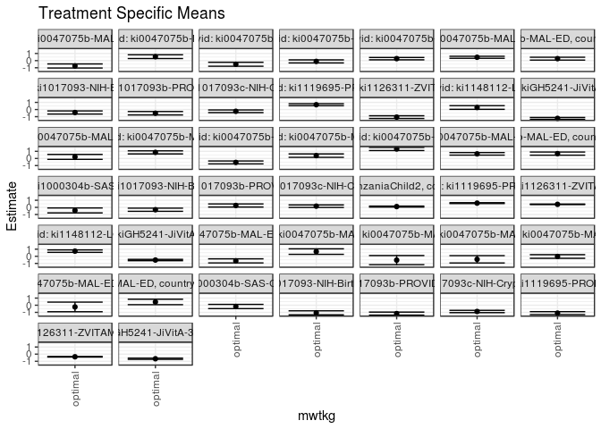

## Results Table

### Parameter: TSM

| agecat | studyid | country | intervention_level | baseline_level | estimate | ci_lower | ci_upper |
| --- | --- | --- | --- | --- | --- | --- | --- |
| Birth | ki0047075b-MAL-ED | BANGLADESH | optimal | observed | -0.6418828 | -0.9276866 | -0.3560790 |
| Birth | ki0047075b-MAL-ED | BRAZIL | optimal | observed | 0.6633629 | 0.2777269 | 1.0489989 |
| Birth | ki0047075b-MAL-ED | INDIA | optimal | observed | -0.5369898 | -1.1780887 | 0.1041091 |
| Birth | ki0047075b-MAL-ED | NEPAL | optimal | observed | -0.4219178 | -0.9357527 | 0.0919171 |
| Birth | ki0047075b-MAL-ED | PERU | optimal | observed | -0.0251933 | -0.2811001 | 0.2307135 |
| Birth | ki0047075b-MAL-ED | SOUTH AFRICA | optimal | observed | -0.2408964 | -0.9161653 | 0.4343724 |
| Birth | ki0047075b-MAL-ED | TANZANIA, UNITED REPUBLIC OF | optimal | observed | 0.4594689 | 0.0764402 | 0.8424975 |
| Birth | ki1000304b-SAS-CompFeed | INDIA | optimal | observed | -0.1800631 | -0.4754676 | 0.1153415 |
| Birth | ki1017093-NIH-Birth | BANGLADESH | optimal | observed | -1.0681252 | -1.3490486 | -0.7872017 |
| Birth | ki1017093b-PROVIDE | BANGLADESH | optimal | observed | -1.1758994 | -1.3862456 | -0.9655532 |
| Birth | ki1017093c-NIH-Crypto | BANGLADESH | optimal | observed | -0.8792941 | -1.0413850 | -0.7172033 |
| Birth | ki1119695-PROBIT | BELARUS | optimal | observed | -1.1061880 | -1.3123974 | -0.8999785 |
| Birth | ki1126311-ZVITAMBO | ZIMBABWE | optimal | observed | -0.3705806 | -0.4110994 | -0.3300617 |
| Birth | kiGH5241-JiVitA-3 | BANGLADESH | optimal | observed | -0.6468173 | -0.7346142 | -0.5590203 |
| 6 months | ki0047075b-MAL-ED | BANGLADESH | optimal | observed | 0.2185807 | -0.1275272 | 0.5646885 |
| 6 months | ki0047075b-MAL-ED | BRAZIL | optimal | observed | 0.8531152 | 0.6392554 | 1.0669750 |
| 6 months | ki0047075b-MAL-ED | INDIA | optimal | observed | -0.5571732 | -0.7617292 | -0.3526171 |
| 6 months | ki0047075b-MAL-ED | NEPAL | optimal | observed | 0.3968851 | 0.1554683 | 0.6383020 |
| 6 months | ki0047075b-MAL-ED | PERU | optimal | observed | 1.3305145 | 1.1123467 | 1.5486823 |
| 6 months | ki0047075b-MAL-ED | SOUTH AFRICA | optimal | observed | 0.6484568 | 0.4677979 | 0.8291157 |
| 6 months | ki0047075b-MAL-ED | TANZANIA, UNITED REPUBLIC OF | optimal | observed | 0.6793144 | 0.4581163 | 0.9005124 |
| 6 months | ki1000304b-SAS-CompFeed | INDIA | optimal | observed | -0.4285106 | -0.7731234 | -0.0838979 |
| 6 months | ki1017093-NIH-Birth | BANGLADESH | optimal | observed | -0.3297639 | -0.5519577 | -0.1075701 |
| 6 months | ki1017093b-PROVIDE | BANGLADESH | optimal | observed | 0.2664357 | 0.0453133 | 0.4875581 |
| 6 months | ki1017093c-NIH-Crypto | BANGLADESH | optimal | observed | 0.1705018 | -0.0070015 | 0.3480052 |
| 6 months | ki1066203-TanzaniaChild2 | TANZANIA, UNITED REPUBLIC OF | optimal | observed | 0.1126746 | 0.0435915 | 0.1817577 |
| 6 months | ki1119695-PROBIT | BELARUS | optimal | observed | 0.5978746 | 0.5336514 | 0.6620978 |
| 6 months | ki1126311-ZVITAMBO | ZIMBABWE | optimal | observed | 0.4276948 | 0.3918741 | 0.4635154 |
| 6 months | ki1148112-LCNI-5 | MALAWI | optimal | observed | 0.7228483 | 0.5498230 | 0.8958737 |
| 6 months | kiGH5241-JiVitA-3 | BANGLADESH | optimal | observed | -0.5234498 | -0.6158486 | -0.4310510 |
| 24 months | ki0047075b-MAL-ED | BANGLADESH | optimal | observed | -0.7527466 | -1.0386790 | -0.4668142 |
| 24 months | ki0047075b-MAL-ED | BRAZIL | optimal | observed | 0.5558938 | 0.2921781 | 0.8196094 |
| 24 months | ki0047075b-MAL-ED | INDIA | optimal | observed | -0.5097583 | -0.7867302 | -0.2327865 |
| 24 months | ki0047075b-MAL-ED | NEPAL | optimal | observed | -0.1105480 | -0.3234036 | 0.1023075 |
| 24 months | ki0047075b-MAL-ED | PERU | optimal | observed | 0.2766086 | 0.1113530 | 0.4418643 |
| 24 months | ki0047075b-MAL-ED | SOUTH AFRICA | optimal | observed | 0.4687532 | 0.3271150 | 0.6103913 |
| 24 months | ki0047075b-MAL-ED | TANZANIA, UNITED REPUBLIC OF | optimal | observed | 0.2751934 | 0.0762460 | 0.4741407 |
| 24 months | ki1017093-NIH-Birth | BANGLADESH | optimal | observed | -0.4167832 | -0.6392193 | -0.1943470 |
| 24 months | ki1017093b-PROVIDE | BANGLADESH | optimal | observed | -0.5178277 | -0.7574205 | -0.2782349 |
| 24 months | ki1017093c-NIH-Crypto | BANGLADESH | optimal | observed | -0.2474603 | -0.4324059 | -0.0625147 |
| 24 months | ki1119695-PROBIT | BELARUS | optimal | observed | 0.6776289 | 0.5347615 | 0.8204963 |
| 24 months | ki1126311-ZVITAMBO | ZIMBABWE | optimal | observed | -1.0656961 | -1.2568963 | -0.8744959 |
| 24 months | ki1148112-LCNI-5 | MALAWI | optimal | observed | 0.2831934 | 0.0265515 | 0.5398353 |
| 24 months | kiGH5241-JiVitA-3 | BANGLADESH | optimal | observed | -1.2432771 | -1.3713472 | -1.1152069 |

### Parameter: E(Y)

| agecat | studyid | country | intervention_level | baseline_level | estimate | ci_lower | ci_upper |
| --- | --- | --- | --- | --- | --- | --- | --- |
| Birth | ki0047075b-MAL-ED | BANGLADESH | observed | observed | -0.9526794 | -1.0978709 | -0.8074880 |
| Birth | ki0047075b-MAL-ED | BRAZIL | observed | observed | 0.4018033 | 0.0834093 | 0.7201973 |
| Birth | ki0047075b-MAL-ED | INDIA | observed | observed | -0.9678049 | -1.2522118 | -0.6833979 |
| Birth | ki0047075b-MAL-ED | NEPAL | observed | observed | -0.7684615 | -1.1257770 | -0.4111460 |
| Birth | ki0047075b-MAL-ED | PERU | observed | observed | -0.0429864 | -0.1658406 | 0.0798678 |
| Birth | ki0047075b-MAL-ED | SOUTH AFRICA | observed | observed | -0.1930000 | -0.4278634 | 0.0418634 |
| Birth | ki0047075b-MAL-ED | TANZANIA, UNITED REPUBLIC OF | observed | observed | 0.7583186 | 0.5636385 | 0.9529987 |
| Birth | ki1000304b-SAS-CompFeed | INDIA | observed | observed | -0.6660770 | -0.8389738 | -0.4931801 |
| Birth | ki1017093-NIH-Birth | BANGLADESH | observed | observed | -1.3499217 | -1.4444634 | -1.2553801 |
| Birth | ki1017093b-PROVIDE | BANGLADESH | observed | observed | -1.3060980 | -1.3843247 | -1.2278714 |
| Birth | ki1017093c-NIH-Crypto | BANGLADESH | observed | observed | -1.2434730 | -1.3276901 | -1.1592559 |
| Birth | ki1119695-PROBIT | BELARUS | observed | observed | -1.1429853 | -1.3532634 | -0.9327073 |
| Birth | ki1126311-ZVITAMBO | ZIMBABWE | observed | observed | -0.4824198 | -0.5113303 | -0.4535093 |
| Birth | kiGH5241-JiVitA-3 | BANGLADESH | observed | observed | -0.7504434 | -0.7683264 | -0.7325603 |
| 6 months | ki0047075b-MAL-ED | BANGLADESH | observed | observed | -0.1383956 | -0.2672708 | -0.0095204 |
| 6 months | ki0047075b-MAL-ED | BRAZIL | observed | observed | 0.9644952 | 0.7999744 | 1.1290160 |
| 6 months | ki0047075b-MAL-ED | INDIA | observed | observed | -0.7036879 | -0.8303672 | -0.5770087 |
| 6 months | ki0047075b-MAL-ED | NEPAL | observed | observed | 0.1110452 | -0.0202712 | 0.2423616 |
| 6 months | ki0047075b-MAL-ED | PERU | observed | observed | 1.0588909 | 0.9369064 | 1.1808755 |
| 6 months | ki0047075b-MAL-ED | SOUTH AFRICA | observed | observed | 0.5297055 | 0.3757432 | 0.6836678 |
| 6 months | ki0047075b-MAL-ED | TANZANIA, UNITED REPUBLIC OF | observed | observed | 0.5362213 | 0.4049390 | 0.6675036 |
| 6 months | ki1000304b-SAS-CompFeed | INDIA | observed | observed | -0.6660835 | -0.8034722 | -0.5286949 |
| 6 months | ki1017093-NIH-Birth | BANGLADESH | observed | observed | -0.4474038 | -0.5378167 | -0.3569909 |
| 6 months | ki1017093b-PROVIDE | BANGLADESH | observed | observed | -0.1987071 | -0.2815473 | -0.1158669 |
| 6 months | ki1017093c-NIH-Crypto | BANGLADESH | observed | observed | 0.0297622 | -0.0491685 | 0.1086930 |
| 6 months | ki1066203-TanzaniaChild2 | TANZANIA, UNITED REPUBLIC OF | observed | observed | 0.0780261 | 0.0247830 | 0.1312691 |
| 6 months | ki1119695-PROBIT | BELARUS | observed | observed | 0.5834072 | 0.5254491 | 0.6413653 |
| 6 months | ki1126311-ZVITAMBO | ZIMBABWE | observed | observed | 0.2987004 | 0.2725093 | 0.3248915 |
| 6 months | ki1148112-LCNI-5 | MALAWI | observed | observed | 0.4518519 | 0.3806435 | 0.5230602 |
| 6 months | kiGH5241-JiVitA-3 | BANGLADESH | observed | observed | -0.5929476 | -0.6125268 | -0.5733684 |
| 24 months | ki0047075b-MAL-ED | BANGLADESH | observed | observed | -0.8201887 | -0.9423967 | -0.6979806 |
| 24 months | ki0047075b-MAL-ED | BRAZIL | observed | observed | 0.4409524 | 0.2364865 | 0.6454182 |
| 24 months | ki0047075b-MAL-ED | INDIA | observed | observed | -0.9525664 | -1.0684455 | -0.8366872 |
| 24 months | ki0047075b-MAL-ED | NEPAL | observed | observed | -0.3764474 | -0.4898516 | -0.2630431 |
| 24 months | ki0047075b-MAL-ED | PERU | observed | observed | 0.1204478 | 0.0005049 | 0.2403906 |
| 24 months | ki0047075b-MAL-ED | SOUTH AFRICA | observed | observed | 0.3975641 | 0.2766504 | 0.5184778 |
| 24 months | ki0047075b-MAL-ED | TANZANIA, UNITED REPUBLIC OF | observed | observed | 0.0539486 | -0.0712465 | 0.1791437 |
| 24 months | ki1017093-NIH-Birth | BANGLADESH | observed | observed | -0.9115790 | -1.0095022 | -0.8136559 |
| 24 months | ki1017093b-PROVIDE | BANGLADESH | observed | observed | -0.8914360 | -0.9741797 | -0.8086923 |
| 24 months | ki1017093c-NIH-Crypto | BANGLADESH | observed | observed | -0.6103502 | -0.7050157 | -0.5156847 |
| 24 months | ki1119695-PROBIT | BELARUS | observed | observed | 0.6888304 | 0.5749159 | 0.8027449 |
| 24 months | ki1126311-ZVITAMBO | ZIMBABWE | observed | observed | -1.1835154 | -1.2835950 | -1.0834359 |
| 24 months | ki1148112-LCNI-5 | MALAWI | observed | observed | -0.0466281 | -0.1286250 | 0.0353688 |
| 24 months | kiGH5241-JiVitA-3 | BANGLADESH | observed | observed | -1.2990730 | -1.3224430 | -1.2757030 |

### Parameter: PAR

| agecat | studyid | country | intervention_level | baseline_level | estimate | ci_lower | ci_upper |
| --- | --- | --- | --- | --- | --- | --- | --- |
| Birth | ki0047075b-MAL-ED | BANGLADESH | optimal | observed | -0.3107966 | -0.5846028 | -0.0369904 |
| Birth | ki0047075b-MAL-ED | BRAZIL | optimal | observed | -0.2615596 | -0.5622369 | 0.0391176 |
| Birth | ki0047075b-MAL-ED | INDIA | optimal | observed | -0.4308151 | -1.0490591 | 0.1874290 |
| Birth | ki0047075b-MAL-ED | NEPAL | optimal | observed | -0.3465437 | -0.8241349 | 0.1310474 |
| Birth | ki0047075b-MAL-ED | PERU | optimal | observed | -0.0177931 | -0.2370771 | 0.2014909 |
| Birth | ki0047075b-MAL-ED | SOUTH AFRICA | optimal | observed | 0.0478964 | -0.5341645 | 0.6299574 |
| Birth | ki0047075b-MAL-ED | TANZANIA, UNITED REPUBLIC OF | optimal | observed | 0.2988497 | -0.0209591 | 0.6186585 |
| Birth | ki1000304b-SAS-CompFeed | INDIA | optimal | observed | -0.4860139 | -0.6721138 | -0.2999140 |
| Birth | ki1017093-NIH-Birth | BANGLADESH | optimal | observed | -0.2817966 | -0.5430004 | -0.0205927 |
| Birth | ki1017093b-PROVIDE | BANGLADESH | optimal | observed | -0.1301986 | -0.3197220 | 0.0593248 |
| Birth | ki1017093c-NIH-Crypto | BANGLADESH | optimal | observed | -0.3641789 | -0.5065328 | -0.2218250 |
| Birth | ki1119695-PROBIT | BELARUS | optimal | observed | -0.0367974 | -0.0572342 | -0.0163605 |
| Birth | ki1126311-ZVITAMBO | ZIMBABWE | optimal | observed | -0.1118392 | -0.1394875 | -0.0841909 |
| Birth | kiGH5241-JiVitA-3 | BANGLADESH | optimal | observed | -0.1036261 | -0.1888955 | -0.0183567 |
| 6 months | ki0047075b-MAL-ED | BANGLADESH | optimal | observed | -0.3569763 | -0.6751426 | -0.0388100 |
| 6 months | ki0047075b-MAL-ED | BRAZIL | optimal | observed | 0.1113800 | -0.0684729 | 0.2912330 |
| 6 months | ki0047075b-MAL-ED | INDIA | optimal | observed | -0.1465148 | -0.3552615 | 0.0622319 |
| 6 months | ki0047075b-MAL-ED | NEPAL | optimal | observed | -0.2858399 | -0.4811524 | -0.0905275 |
| 6 months | ki0047075b-MAL-ED | PERU | optimal | observed | -0.2716236 | -0.4494262 | -0.0938209 |
| 6 months | ki0047075b-MAL-ED | SOUTH AFRICA | optimal | observed | -0.1187513 | -0.2185275 | -0.0189752 |
| 6 months | ki0047075b-MAL-ED | TANZANIA, UNITED REPUBLIC OF | optimal | observed | -0.1430931 | -0.3452323 | 0.0590462 |
| 6 months | ki1000304b-SAS-CompFeed | INDIA | optimal | observed | -0.2375729 | -0.4627336 | -0.0124122 |
| 6 months | ki1017093-NIH-Birth | BANGLADESH | optimal | observed | -0.1176399 | -0.3298178 | 0.0945381 |
| 6 months | ki1017093b-PROVIDE | BANGLADESH | optimal | observed | -0.4651428 | -0.6643863 | -0.2658993 |
| 6 months | ki1017093c-NIH-Crypto | BANGLADESH | optimal | observed | -0.1407396 | -0.2971806 | 0.0157014 |
| 6 months | ki1066203-TanzaniaChild2 | TANZANIA, UNITED REPUBLIC OF | optimal | observed | -0.0346485 | -0.0777118 | 0.0084148 |
| 6 months | ki1119695-PROBIT | BELARUS | optimal | observed | -0.0144674 | -0.0382915 | 0.0093566 |
| 6 months | ki1126311-ZVITAMBO | ZIMBABWE | optimal | observed | -0.1289944 | -0.1544231 | -0.1035657 |
| 6 months | ki1148112-LCNI-5 | MALAWI | optimal | observed | -0.2709965 | -0.4349108 | -0.1070822 |
| 6 months | kiGH5241-JiVitA-3 | BANGLADESH | optimal | observed | -0.0694978 | -0.1599069 | 0.0209113 |
| 24 months | ki0047075b-MAL-ED | BANGLADESH | optimal | observed | -0.0674421 | -0.3251981 | 0.1903140 |
| 24 months | ki0047075b-MAL-ED | BRAZIL | optimal | observed | -0.1149414 | -0.2699418 | 0.0400590 |
| 24 months | ki0047075b-MAL-ED | INDIA | optimal | observed | -0.4428080 | -0.6998023 | -0.1858138 |
| 24 months | ki0047075b-MAL-ED | NEPAL | optimal | observed | -0.2658993 | -0.4339589 | -0.0978398 |
| 24 months | ki0047075b-MAL-ED | PERU | optimal | observed | -0.1561609 | -0.3090762 | -0.0032456 |
| 24 months | ki0047075b-MAL-ED | SOUTH AFRICA | optimal | observed | -0.0711891 | -0.1497088 | 0.0073307 |
| 24 months | ki0047075b-MAL-ED | TANZANIA, UNITED REPUBLIC OF | optimal | observed | -0.2212448 | -0.3859315 | -0.0565581 |
| 24 months | ki1017093-NIH-Birth | BANGLADESH | optimal | observed | -0.4947959 | -0.7076074 | -0.2819843 |
| 24 months | ki1017093b-PROVIDE | BANGLADESH | optimal | observed | -0.3736083 | -0.5883401 | -0.1588766 |
| 24 months | ki1017093c-NIH-Crypto | BANGLADESH | optimal | observed | -0.3628899 | -0.5234030 | -0.2023767 |
| 24 months | ki1119695-PROBIT | BELARUS | optimal | observed | 0.0112015 | -0.0745932 | 0.0969962 |
| 24 months | ki1126311-ZVITAMBO | ZIMBABWE | optimal | observed | -0.1178194 | -0.2849322 | 0.0492935 |
| 24 months | ki1148112-LCNI-5 | MALAWI | optimal | observed | -0.3298215 | -0.5677517 | -0.0918913 |
| 24 months | kiGH5241-JiVitA-3 | BANGLADESH | optimal | observed | -0.0557959 | -0.1823337 | 0.0707419 |